# Análise da Covariância no R

# 1 O que vamos executar?

- Verificar os pressupostos da ANCOVA;
- Montar e interpretar o modelo de ANCOVA;
- Analisar a diferença entre os grupos pelas “médias marginais estimadas” e por teste de *post-hoc* (*Turkey*);
- Pedir as médias ajustadas;
- Descrever os resultados.

Existem muitos pressupostos para a análise da covariância (ANCOVA) que precisa ser detalhada a fim de validar a informação extraída. Sabemos que a ANCOVA é uma ANOVA que inclui uma covariável, que será independente, contínua (numérica) e que vai entrar no modelo como uma variável de controle.

**Pressupostos:**  
* Independência entre a covariável e a variável independente (VI);  
* Relação linear entre a variável dependente (VD) e a covariável;  
* Homogeneidade dos parâmetros de regressão;  
* Homogeneidade de variâncias;  
* Normalidade dos resíduos;  
* Homocedasticidade e ausência de *outliers*.

# 2 Situação problema

O `Banco de Dados 8.csv` contém informações de 30 indivíduos. Verifique se o grau de instrução desses indivíduos tem efeito sobre os seus salários, controlando esse efeito pela idade. Descreva os resultados de forma apropriada.

# 3 Efetuando a Análise

É necessário seguir alguns passos importantes.

## 3.1 Passo 1: Carregar os pacotes de dados

```r
if(!require(dplyr)) install.packages("dplyr")
library(dplyr)
if(!require(rstatix)) install.packages("rstatix")
library(rstatix)
if(!require(car)) install.packages("car")
library(car)
if(!require(ggplot2)) install.packages("ggplot2")
library(ggplot2)
if(!require(multcomp)) install.packages("multcomp")
library(multcomp)
if(!require(emmeans)) install.packages("emmeans")
library(emmeans)
```

## 3.2 Passo 2: Carregar o banco de dados.

Detalhe importante: selecionar o diretório de trabalho via *Session/Set Working Directory/Choose Directory*.

```r
dados <- read.csv2('Banco de Dados 8.csv', encoding = 'latin1')
glimpse(dados)
```

```
## Rows: 30
## Columns: 6
## $ Sujeito        <int> 1, 2, 3, 4, 5, 6, 7, 8, 9, 10, 11, 12, 13, 14, 15, 16, ~
## $ Gênero         <chr> "M", "F", "M", "M", "F", "F", "M", "M", "M", "M", "F", ~
## $ Grau_Instrução <chr> "Superior", "Superior", "Superior", "Ens Fundamental", ~
## $ n_Filhos       <int> 1, 0, 0, 0, 0, 2, 0, 0, 1, 2, 0, 3, 0, 0, 1, 1, 0, 0, 2~
## $ Idade          <int> 31, 25, 33, 20, 23, 37, 38, 37, 34, 40, 41, 46, 26, 41,~
## $ Salário        <dbl> 8.2, 5.3, 9.4, 2.9, 3.7, 4.4, 4.7, 5.4, 5.8, 3.2, 6.0, ~
```

```r
library(rmarkdown)
paged_table(dados)
```

| Sujeito | Gênero | Grau_Instrução | n_Filhos | Idade | Salário |
| --- | --- | --- | --- | --- | --- |
| 1 | M | Superior | 1 | 31 | 8.2 |
| 2 | F | Superior | 0 | 25 | 5.3 |
| 3 | M | Superior | 0 | 33 | 9.4 |
| 4 | M | Ens Fundamental | 0 | 20 | 2.9 |
| 5 | F | Ensino Médio | 0 | 23 | 3.7 |
| 6 | F | Superior | 2 | 37 | 4.4 |
| 7 | M | Ens Fundamental | 0 | 38 | 4.7 |
| 8 | M | Superior | 0 | 37 | 5.4 |
| 9 | M | Superior | 1 | 34 | 5.8 |
| 10 | M | Ensino Médio | 2 | 40 | 3.2 |

[output cut: 20 more lines]

Lembrar sempre que quando usamos `glimpse` é para verificar a categoria da variável dentro de seus respectivos grupos. Por exemplo, as variáveis `Sujeito`, `n_Filhos` e `Idade` estão representadas por `<int>` que significa que os dados são apresentados em números inteiros; as variáveis `Genero` e `Grau_Instrução` estão como `<chr>` que significa que são caracteres; a variável `Salário` está representada por `<dbl>`, que significa número real com uma casa decimal (*double*).

Teremos assim o modelo econométrico representado por:  
**Variável Dependente (VD):** `Salário`  
**Variável Independente (VI):** `Grau_Instrução`  
**Covariável**: `Idade`

## 3.3 Passo 3: Verificar se existe efeito da VI sobre a covariável (cov ~ VI)

Pressuposto: “independência entre a VI e a covariável”  
Se rompido: não há outro modelo - é um problema de delineamento experimental.

```r
mod_cov <- aov(Idade ~ Grau_Instrução, data = dados)
summary(mod_cov)
```

```
##                Df Sum Sq Mean Sq F value Pr(>F)
## Grau_Instrução  2   20.4   10.21   0.227  0.799
## Residuals      27 1215.4   45.02
```

Usamos a função `aov` porque é uma função de análise de variância e, nesse caso, colocamos a variável `Idade` como VD (pois é a nossa covariável), e o `Grau_Instrução` como VI.

Verificamos com a função `summary` que o modelo efetua uma ANOVA com `F-value`, graus de liberdade (`Df`), média, e um `p-value` dado por `Pr(>F)`., onde `p > 0.05`, o que nos permite interpretar aceitando a hipótese nula que, nesse caso, será:

- H<sub>0</sub>: **não** há efeito do grau de instrução sobre a idade → p > 0,05
- H<sub>0</sub>: há efeito do grau de instrução sobre a idade → p ≤ 0,05

Verificamos então que esse pressuposto foi atendido - *e é o que precisamos prestar mais atenção!*

## 3.4 Passo 4: Verificar se a relação entre a covariável e a VD é linear (VD ~ cov)

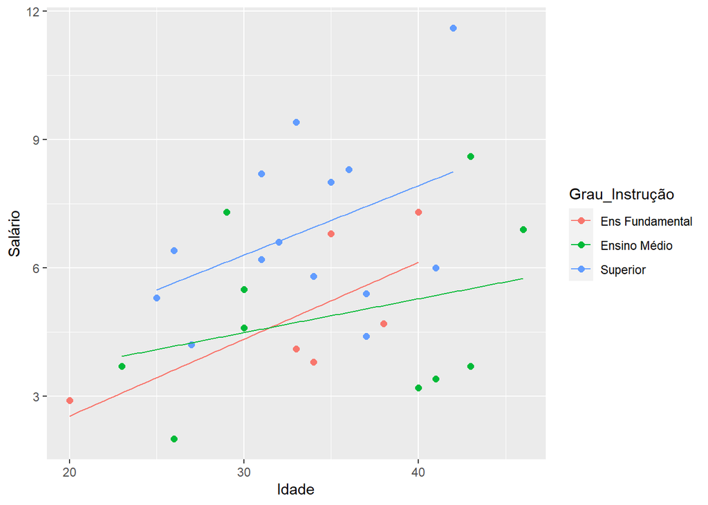

```r
ggplot(data = dados, aes(x = Idade, y = Salário, group = Grau_Instrução,
                         color = Grau_Instrução)) +
  geom_point(size = 2) +
  xlab('Idade') +
  ylab('Salário') +
  geom_smooth(method = "lm", se = FALSE, size = 0.5)
```

Nesse caso, verificamos que existe uma relação entre idade e salário, que aponta que o salário aumenta conforme a idade também aumenta.

## 3.5 Passo 5: Verificar se o efeito da covariável é o mesmo para todos níveis da VI (VD ~ VI*cov)

Pressuposto: “homogeneidade dos parâmetros de regressão”  
Compara as inclinações das retas para cada grupo da VI.

```r
mod_int <- aov(Salário ~ Grau_Instrução*Idade, data = dados)
Anova(mod_int, type = 'III')
```

```
## Anova Table (Type III tests)
##
## Response: Salário
##                      Sum Sq Df F value Pr(>F)
## (Intercept)           0.239  1  0.0645 0.8017
## Grau_Instrução        1.508  2  0.2035 0.8173
## Idade                 7.982  1  2.1539 0.1552
## Grau_Instrução:Idade  2.522  2  0.3402 0.7150
## Residuals            88.946 24
```

Efetuamos um novo modelo, com a regressão dada pela VD `Salário` condicionada ao `Grau_Instrução` interagindo com a variável de referência (covariável) `Idade`. Com a regressão feita, verificamos os parâmetros não mais com a função `summary`, mas sim com a `Anova` porque queremos que o resultado seja analisado a partir da soma dos quadrados do tipo III (ver a aula de ANOVA de duas vias).

- H<sub>0</sub>: existe homogeneidade dos parâmetros de regressão → p > 0,05
- H<sub>0</sub>: **não** existe homogeneidade dos parâmetros de regressão → p ≤ 0,05

Para vermos se as retas possuem a mesma inclinação, a interação entre `Grau_Instrução` e `Idade` não vai ser estatisticamente significativa `p > 0.05`, caracterizando hipótese nula para esse teste. Logo, vemos que todos os valores de `Pr(>F)` serão maiores que 5%, logo *existe homogeneidade dos parâmetros*.

## 3.6 Passo 6: Verificar se há homogeneidade de variâncias (VD ~ VI)

Se rompido: versão robusta da ANCOVA

```r
leveneTest(Salário ~ Grau_Instrução, center = mean, data = dados)
```

```
## Levene's Test for Homogeneity of Variance (center = mean)
##       Df F value Pr(>F)
## group  2  0.1854 0.8318
##       27
```

Os pressupostos do *Teste de Levene* são:

- H<sub>0</sub>: As variâncias dos grupos são homogêneas → p > 0,05
- H<sub>1</sub>: As variâncias dos grupos **não** são homogêneas → p ≤ 0,05

Rodando o teste, verificamos `Pr(>F) > 0.05`, com valores estatisticamente não significantes, o que implica que os pressupostos até aqui foram todos atendidos.

## 3.7 Passo 7: Ajustar o modelo de ANCOVA (VD ~ cov + VI)

Tendo os pressupostos todos atendidos, efetuamos o modelo da ANCOVA.  
Se os resultados forem avaliados pelo tipo I da soma dos quadrados, é obrigatório que a covariável seja inserida antes no modelo.

```r
options(contrasts = c("contr.sum", "contr.poly"))
mod_ANCOVA <- aov(Salário ~ Idade + Grau_Instrução, data = dados)
Anova(mod_ANCOVA, type = 'III')
```

```
## Anova Table (Type III tests)
##
## Response: Salário
##                Sum Sq Df F value  Pr(>F)
## (Intercept)     1.914  1  0.5440 0.46739
## Idade          18.470  1  5.2501 0.03030 *
## Grau_Instrução 31.968  2  4.5436 0.02031 *
## Residuals      91.467 26
## ---
## Signif. codes:  0 '***' 0.001 '**' 0.01 '*' 0.05 '.' 0.1 ' ' 1
```

Agora sim podemos analisar os resultados de `p-value` para verificar se são estatisticamente significantes para as variáveis analisadas. Temos que a implicação do `Grau_Instrução`, controlado pela `Idade`, são menores que 5%, o que significa que têm impacto sobre o valor de `Salário`.

## 3.8 Passo 8: Verificar a normalidade dos resíduos

Se rompido: versão robusta da ANCOVA

```r
shapiro.test(mod_ANCOVA$residuals)
```

```
##
##  Shapiro-Wilk normality test
##
## data:  mod_ANCOVA$residuals
## W = 0.96498, p-value = 0.4122
```

Lembrando que os pressupostos do *Teste de Shapiro-Wilk* são:

- H<sub>0</sub>: Distribuição dos dados = normal → p > 0,05
- H<sub>1</sub>: Distribuição dos dados ≠ normal → p ≤ 0,05

Nesse caso, como `p-value > 0.05`, consideramos que os resíduos têm distribuição normal.

## 3.9 Passo 9: Verificar se há homocedasticidade e *outliers*

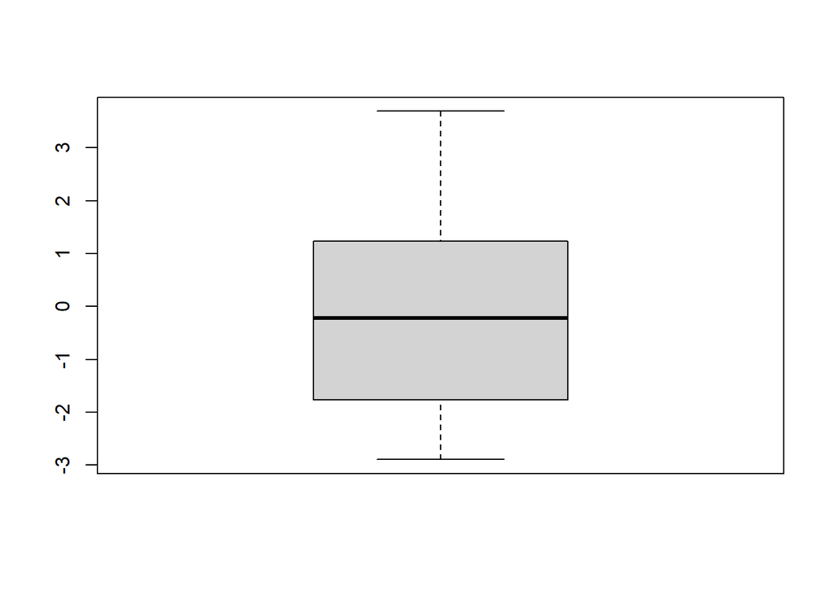

```r
boxplot(mod_ANCOVA$residuals)
```

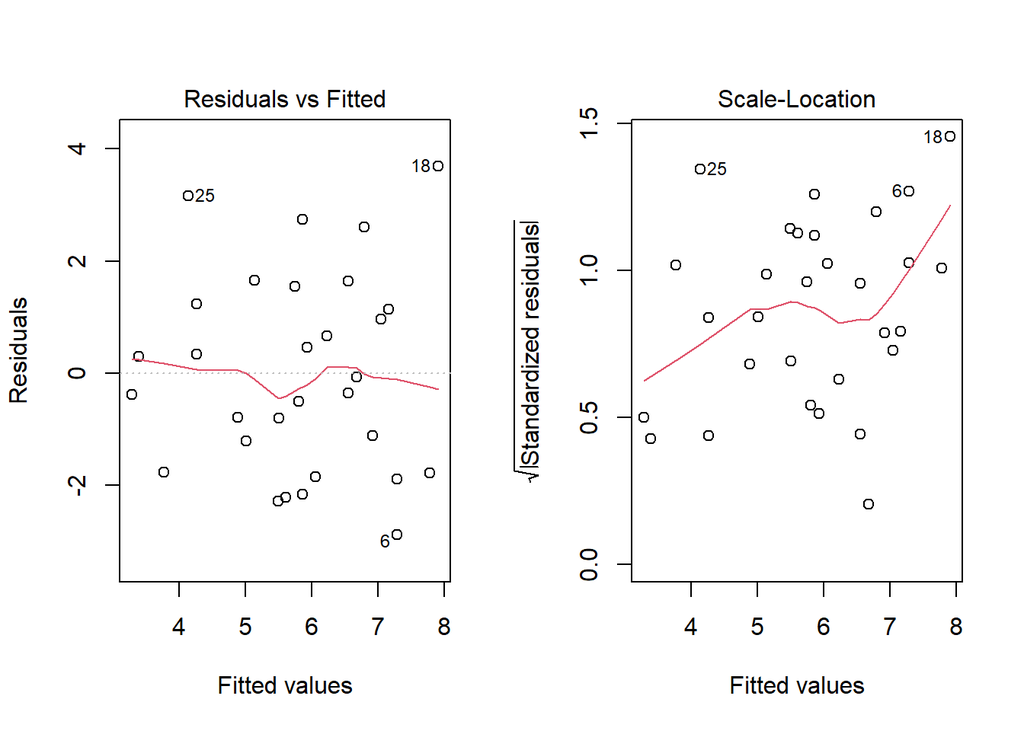

```r
par(mfrow=c(1,2))
plot(mod_ANCOVA, which=c(1,3))
```

```r
leveneTest(mod_ANCOVA$residuals ~ dados$Grau_Instrução)
```

```
## Levene's Test for Homogeneity of Variance (center = median)
##       Df F value Pr(>F)
## group  2  0.7856  0.466
##       27
```

Analisando os gráficos, primeiro do `boxplot`, verificamos que o modelo não possui *outliers* e, conforme os dois gráficos subsequentes, como os dados estão distribuídos de maneira homogênea, entendemos que há homocedasticidade no modelo. Além disso, também efetuamos um `Levene-test` para os resíduos, em que `p-value > 0.05`, o que nos permite concluir que as variâncias estão também homogêneas.

## 3.10 Passo 10: Realização das comparações entre grupos

### 3.10.1 Pelo pacote `multcomp`

```r
library(multcomp)
dados$Grau_Instrução <- factor(dados$Grau_Instrução)
mod_ANCOVA <- aov(Salário ~ Idade + Grau_Instrução, data = dados)
posthoc <- glht(mod_ANCOVA, linfct = mcp(Grau_Instrução = "Tukey"))
summary(posthoc)
```

```
##
##   Simultaneous Tests for General Linear Hypotheses
##
## Multiple Comparisons of Means: Tukey Contrasts
##
##
## Fit: aov(formula = Salário ~ Idade + Grau_Instrução, data = dados)
##
## Linear Hypotheses:
##                                     Estimate Std. Error t value Pr(>|t|)
## Ensino Médio - Ens Fundamental == 0  -0.2611     0.9732  -0.268   0.9609
## Superior - Ens Fundamental == 0       1.9066     0.9152   2.083   0.1122
## Superior - Ensino Médio == 0          2.1677     0.7822   2.771   0.0265 *
## ---
## Signif. codes:  0 '***' 0.001 '**' 0.01 '*' 0.05 '.' 0.1 ' ' 1
## (Adjusted p values reported -- single-step method)
```

```r
## Outra opção: `Dunnett`, que compara todo o grupo com a variável de controle.
```

Verificamos então que o modelo apresenta diferença estatisticamente significante apenas entre os dados para a diferença entre ensino superior e ensino médio, com `Pr(>|t|) < 0.05`.

### 3.10.2 Pelo `rstatix`

```r
comparacoes <- dados %>% emmeans_test(Salário ~ Grau_Instrução, covariate = Idade,
                       p.adjust.method = "bonferroni")
comparacoes
```

```
## # A tibble: 3 x 9
##   term                 .y.     group1 group2    df stati~1      p  p.adj p.adj~2
## * <chr>                <chr>   <chr>  <chr>  <dbl>   <dbl>  <dbl>  <dbl> <chr>
## 1 Idade*Grau_Instrução Salário Ens F~ Ensin~    26   0.268 0.791  1      ns
## 2 Idade*Grau_Instrução Salário Ens F~ Super~    26  -2.08  0.0472 0.142  ns
## 3 Idade*Grau_Instrução Salário Ensin~ Super~    26  -2.77  0.0102 0.0305 *
## # ... with abbreviated variable names 1: statistic, 2: p.adj.signif
```

O pacote “emmeans” (Estimated Marginal Means) é usado para realizar análises de médias marginais estimadas. Ele fornece uma maneira conveniente de calcular e interpretar as médias marginais em modelos lineares, generalizados e mistos.

Também oferece funcionalidades para realizar contrastes, comparações múltiplas, intervalos de confiança e gráficos relacionados às médias marginais estimadas. É especialmente útil quando você deseja comparar grupos específicos ou fazer inferências sobre os efeitos médios das variáveis em seus modelos.

Nesse caso, verificamos também que a diferença é apenas entre os dados observados para Ensino Superior e Ensino Médio, com `p-value < 0.05`.

## 3.11 Passo 11: Obtenção das médias ajustadas

### 3.11.1 Opção 1:

```r
medias_ajustadas <- emmeans(mod_ANCOVA, ~ Idade:Grau_Instrução)
medias_ajustadas
```

```
##  Idade Grau_Instrução  emmean    SE df lower.CL upper.CL
##   33.9 Ens Fundamental   5.01 0.766 26     3.43     6.58
##   33.9 Ensino Médio      4.75 0.596 26     3.52     5.97
##   33.9 Superior          6.91 0.502 26     5.88     7.95
##
## Confidence level used: 0.95
```

### 3.11.2 Opção 2:

```r
get_emmeans(comparacoes)
```

```
## # A tibble: 3 x 8
##   Idade Grau_Instrução  emmean    se    df conf.low conf.high method
##   <dbl> <fct>            <dbl> <dbl> <dbl>    <dbl>     <dbl> <chr>
## 1  33.9 Ens Fundamental   5.01 0.766    26     3.43      6.58 Emmeans test
## 2  33.9 Ensino Médio      4.75 0.596    26     3.52      5.97 Emmeans test
## 3  33.9 Superior          6.91 0.502    26     5.88      7.95 Emmeans test
```

### 3.11.3 Médias reais:

```r
dados %>% group_by(Grau_Instrução) %>%
  get_summary_stats(Salário, type = "mean_sd")
```

```
## # A tibble: 3 x 5
##   Grau_Instrução  variable     n  mean    sd
##   <fct>           <fct>    <dbl> <dbl> <dbl>
## 1 Ens Fundamental Salário      6  4.93  1.75
## 2 Ensino Médio    Salário     10  4.89  2.12
## 3 Superior        Salário     14  6.84  2.04
```

# 4 Resultados

O modelo de ANCOVA mostrou que há efeito do grau de instrução sobre o salário [F(2,26) = 4,54; p = 0,020], quando controlado pela idade do indivíduo. As comparações entre pares mostraram que há diferença entre os salários do grupo “ensino médio” e do grupo “ensino superior”, sendo que esse último grupo apresenta, em média, salários maiores.